# Optimal Treatment Analysis

## Outcome Variable

**Outcome Variable:** ever_wasted

## Predictor Variables

**Intervention Variable:** feducyrs

**Adjustment Set:**

- arm
- W_mage
- meducyrs
- W_mhtcm
- W_mwtkg
- W_gagebrth
- W_birthwt
- W_birthlen
- single
- delta_W_mage
- delta_meducyrs
- delta_W_mhtcm
- delta_W_mwtkg
- delta_W_gagebrth
- delta_W_birthwt
- delta_W_birthlen
- delta_single

## Stratifying Variables

The analysis was stratified on these variable(s):

- agecat
- studyid
- country

## Data Summary

| agecat | studyid | country | feducyrs | ever_wasted | n_cell | n |
| --- | --- | --- | --- | --- | --- | --- |
| 0-24 months | ki0047075b-MAL-ED | BANGLADESH | High | 0 | 41 | 147 |
| 0-24 months | ki0047075b-MAL-ED | BANGLADESH | High | 1 | 13 | 147 |
| 0-24 months | ki0047075b-MAL-ED | BANGLADESH | Low | 0 | 23 | 147 |
| 0-24 months | ki0047075b-MAL-ED | BANGLADESH | Low | 1 | 16 | 147 |
| 0-24 months | ki0047075b-MAL-ED | BANGLADESH | Medium | 0 | 36 | 147 |
| 0-24 months | ki0047075b-MAL-ED | BANGLADESH | Medium | 1 | 18 | 147 |
| 0-24 months | ki0047075b-MAL-ED | INDIA | High | 0 | 22 | 147 |
| 0-24 months | ki0047075b-MAL-ED | INDIA | High | 1 | 22 | 147 |
| 0-24 months | ki0047075b-MAL-ED | INDIA | Low | 0 | 28 | 147 |
| 0-24 months | ki0047075b-MAL-ED | INDIA | Low | 1 | 31 | 147 |
| 0-24 months | ki0047075b-MAL-ED | INDIA | Medium | 0 | 27 | 147 |
| 0-24 months | ki0047075b-MAL-ED | INDIA | Medium | 1 | 17 | 147 |
| 0-24 months | ki0047075b-MAL-ED | NEPAL | High | 0 | 32 | 98 |
| 0-24 months | ki0047075b-MAL-ED | NEPAL | High | 1 | 10 | 98 |
| 0-24 months | ki0047075b-MAL-ED | NEPAL | Low | 0 | 18 | 98 |
| 0-24 months | ki0047075b-MAL-ED | NEPAL | Low | 1 | 10 | 98 |
| 0-24 months | ki0047075b-MAL-ED | NEPAL | Medium | 0 | 19 | 98 |
| 0-24 months | ki0047075b-MAL-ED | NEPAL | Medium | 1 | 9 | 98 |
| 0-24 months | ki0047075b-MAL-ED | PERU | High | 0 | 112 | 250 |
| 0-24 months | ki0047075b-MAL-ED | PERU | High | 1 | 8 | 250 |
| 0-24 months | ki0047075b-MAL-ED | PERU | Low | 0 | 65 | 250 |
| 0-24 months | ki0047075b-MAL-ED | PERU | Low | 1 | 4 | 250 |
| 0-24 months | ki0047075b-MAL-ED | PERU | Medium | 0 | 54 | 250 |
| 0-24 months | ki0047075b-MAL-ED | PERU | Medium | 1 | 7 | 250 |
| 0-24 months | ki0047075b-MAL-ED | SOUTH AFRICA | High | 0 | 36 | 110 |
| 0-24 months | ki0047075b-MAL-ED | SOUTH AFRICA | High | 1 | 7 | 110 |
| 0-24 months | ki0047075b-MAL-ED | SOUTH AFRICA | Low | 0 | 30 | 110 |
| 0-24 months | ki0047075b-MAL-ED | SOUTH AFRICA | Low | 1 | 7 | 110 |
| 0-24 months | ki0047075b-MAL-ED | SOUTH AFRICA | Medium | 0 | 23 | 110 |
| 0-24 months | ki0047075b-MAL-ED | SOUTH AFRICA | Medium | 1 | 7 | 110 |

[output cut: 330 more lines]

The following strata were considered:

- agecat: 0-24 months, studyid: ki0047075b-MAL-ED, country: BANGLADESH
- agecat: 0-24 months, studyid: ki0047075b-MAL-ED, country: INDIA
- agecat: 0-24 months, studyid: ki0047075b-MAL-ED, country: NEPAL
- agecat: 0-24 months, studyid: ki0047075b-MAL-ED, country: PERU
- agecat: 0-24 months, studyid: ki0047075b-MAL-ED, country: SOUTH AFRICA
- agecat: 0-24 months, studyid: ki0047075b-MAL-ED, country: TANZANIA, UNITED REPUBLIC OF
- agecat: 0-24 months, studyid: ki1000304b-SAS-CompFeed, country: INDIA
- agecat: 0-24 months, studyid: ki1000304b-SAS-FoodSuppl, country: INDIA
- agecat: 0-24 months, studyid: ki1017093b-PROVIDE, country: BANGLADESH
- agecat: 0-24 months, studyid: ki1017093c-NIH-Crypto, country: BANGLADESH
- agecat: 0-24 months, studyid: ki1066203-TanzaniaChild2, country: TANZANIA, UNITED REPUBLIC OF
- agecat: 0-24 months, studyid: ki1113344-GMS-Nepal, country: NEPAL
- agecat: 0-24 months, studyid: ki1119695-PROBIT, country: BELARUS
- agecat: 0-24 months, studyid: ki1126311-ZVITAMBO, country: ZIMBABWE
- agecat: 0-24 months, studyid: ki1135781-COHORTS, country: GUATEMALA
- agecat: 0-24 months, studyid: ki1135781-COHORTS, country: INDIA
- agecat: 0-24 months, studyid: ki1135781-COHORTS, country: PHILIPPINES
- agecat: 0-24 months, studyid: ki1148112-LCNI-5, country: MALAWI
- agecat: 0-24 months, studyid: kiGH5241-JiVitA-3, country: BANGLADESH
- agecat: 0-24 months, studyid: kiGH5241-JiVitA-4, country: BANGLADESH
- agecat: 0-6 months, studyid: ki0047075b-MAL-ED, country: BANGLADESH
- agecat: 0-6 months, studyid: ki0047075b-MAL-ED, country: INDIA
- agecat: 0-6 months, studyid: ki0047075b-MAL-ED, country: NEPAL
- agecat: 0-6 months, studyid: ki0047075b-MAL-ED, country: PERU
- agecat: 0-6 months, studyid: ki0047075b-MAL-ED, country: SOUTH AFRICA
- agecat: 0-6 months, studyid: ki0047075b-MAL-ED, country: TANZANIA, UNITED REPUBLIC OF
- agecat: 0-6 months, studyid: ki1000304b-SAS-CompFeed, country: INDIA
- agecat: 0-6 months, studyid: ki1000304b-SAS-FoodSuppl, country: INDIA
- agecat: 0-6 months, studyid: ki1017093b-PROVIDE, country: BANGLADESH
- agecat: 0-6 months, studyid: ki1017093c-NIH-Crypto, country: BANGLADESH
- agecat: 0-6 months, studyid: ki1066203-TanzaniaChild2, country: TANZANIA, UNITED REPUBLIC OF
- agecat: 0-6 months, studyid: ki1113344-GMS-Nepal, country: NEPAL
- agecat: 0-6 months, studyid: ki1119695-PROBIT, country: BELARUS
- agecat: 0-6 months, studyid: ki1126311-ZVITAMBO, country: ZIMBABWE
- agecat: 0-6 months, studyid: ki1135781-COHORTS, country: GUATEMALA
- agecat: 0-6 months, studyid: ki1135781-COHORTS, country: INDIA
- agecat: 0-6 months, studyid: ki1135781-COHORTS, country: PHILIPPINES
- agecat: 0-6 months, studyid: ki1148112-LCNI-5, country: MALAWI
- agecat: 0-6 months, studyid: kiGH5241-JiVitA-3, country: BANGLADESH
- agecat: 0-6 months, studyid: kiGH5241-JiVitA-4, country: BANGLADESH
- agecat: 6-24 months, studyid: ki0047075b-MAL-ED, country: BANGLADESH
- agecat: 6-24 months, studyid: ki0047075b-MAL-ED, country: INDIA
- agecat: 6-24 months, studyid: ki0047075b-MAL-ED, country: NEPAL
- agecat: 6-24 months, studyid: ki0047075b-MAL-ED, country: PERU
- agecat: 6-24 months, studyid: ki0047075b-MAL-ED, country: SOUTH AFRICA
- agecat: 6-24 months, studyid: ki0047075b-MAL-ED, country: TANZANIA, UNITED REPUBLIC OF
- agecat: 6-24 months, studyid: ki1000304b-SAS-CompFeed, country: INDIA
- agecat: 6-24 months, studyid: ki1000304b-SAS-FoodSuppl, country: INDIA
- agecat: 6-24 months, studyid: ki1017093b-PROVIDE, country: BANGLADESH
- agecat: 6-24 months, studyid: ki1017093c-NIH-Crypto, country: BANGLADESH
- agecat: 6-24 months, studyid: ki1066203-TanzaniaChild2, country: TANZANIA, UNITED REPUBLIC OF
- agecat: 6-24 months, studyid: ki1113344-GMS-Nepal, country: NEPAL
- agecat: 6-24 months, studyid: ki1119695-PROBIT, country: BELARUS
- agecat: 6-24 months, studyid: ki1126311-ZVITAMBO, country: ZIMBABWE
- agecat: 6-24 months, studyid: ki1135781-COHORTS, country: GUATEMALA
- agecat: 6-24 months, studyid: ki1135781-COHORTS, country: INDIA
- agecat: 6-24 months, studyid: ki1135781-COHORTS, country: PHILIPPINES
- agecat: 6-24 months, studyid: ki1148112-LCNI-5, country: MALAWI
- agecat: 6-24 months, studyid: kiGH5241-JiVitA-3, country: BANGLADESH
- agecat: 6-24 months, studyid: kiGH5241-JiVitA-4, country: BANGLADESH

### Dropped Strata

Some strata were dropped due to rare outcomes:

- agecat: 0-24 months, studyid: ki0047075b-MAL-ED, country: PERU
- agecat: 0-24 months, studyid: ki0047075b-MAL-ED, country: TANZANIA, UNITED REPUBLIC OF
- agecat: 0-6 months, studyid: ki0047075b-MAL-ED, country: NEPAL
- agecat: 0-6 months, studyid: ki0047075b-MAL-ED, country: PERU
- agecat: 0-6 months, studyid: ki0047075b-MAL-ED, country: SOUTH AFRICA
- agecat: 0-6 months, studyid: ki0047075b-MAL-ED, country: TANZANIA, UNITED REPUBLIC OF
- agecat: 0-6 months, studyid: ki1000304b-SAS-FoodSuppl, country: INDIA
- agecat: 0-6 months, studyid: ki1148112-LCNI-5, country: MALAWI
- agecat: 6-24 months, studyid: ki0047075b-MAL-ED, country: NEPAL
- agecat: 6-24 months, studyid: ki0047075b-MAL-ED, country: PERU
- agecat: 6-24 months, studyid: ki0047075b-MAL-ED, country: SOUTH AFRICA
- agecat: 6-24 months, studyid: ki0047075b-MAL-ED, country: TANZANIA, UNITED REPUBLIC OF

## Methods Detail

We’re interested in the causal parameters $E[Y_a]$ for all values of $a \in \mathcal{A}$. These parameters represent the mean outcome if, possibly contrary to fact, we intervened to set all units to have $A=a$. Under the randomization and positivity assumptions, these are identified by the statistical parameters $\psi_a=E_W[E_{Y|A,W}(Y|A=a,W)]$. In addition, we’re interested in the mean of $Y$, $E[Y]$ under no intervention (the observed mean). We will estimate these parameters by using SuperLearner to fit the relevant likelihood factors – $E_{Y|A,W}(Y|A=a,W)$ and $p(A=a|W)$, and then updating our likelihood fit using a joint TMLE.

For unadjusted analyses ($W=\{\}$), initial likelihoods were estimated using Lrnr_glm to estimate the simple $E(Y|A)$ and Lrnr_mean to estimate $p(A)$. For adjusted analyses, a small library containing Lrnr_glmnet, Lrnr_xgboost, and Lrnr_mean was used.

Having estimated these parameters, we will then use the delta method to estimate relative risks and attributable risks relative to a prespecified baseline level of $A$.

# Results Detail

## Results Plots

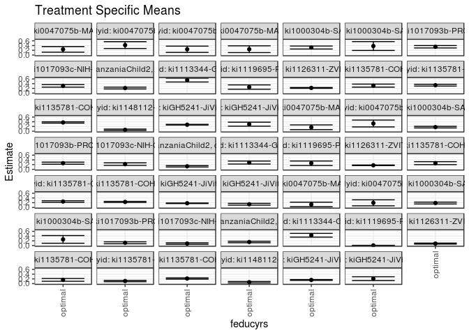

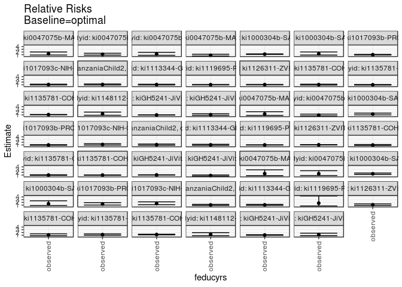

## Results Table

### Parameter: TSM

| agecat | studyid | country | intervention_level | baseline_level | estimate | ci_lower | ci_upper |
| --- | --- | --- | --- | --- | --- | --- | --- |
| 0-24 months | ki0047075b-MAL-ED | BANGLADESH | optimal | NA | 0.2400108 | 0.1226054 | 0.3574161 |
| 0-24 months | ki0047075b-MAL-ED | INDIA | optimal | NA | 0.4186070 | 0.2731334 | 0.5640806 |
| 0-24 months | ki0047075b-MAL-ED | NEPAL | optimal | NA | 0.2435071 | 0.1112232 | 0.3757909 |
| 0-24 months | ki0047075b-MAL-ED | SOUTH AFRICA | optimal | NA | 0.2454393 | 0.1020896 | 0.3887891 |
| 0-24 months | ki1000304b-SAS-CompFeed | INDIA | optimal | NA | 0.3168086 | 0.2541266 | 0.3794907 |
| 0-24 months | ki1000304b-SAS-FoodSuppl | INDIA | optimal | NA | 0.3793381 | 0.1918460 | 0.5668302 |
| 0-24 months | ki1017093b-PROVIDE | BANGLADESH | optimal | NA | 0.3487660 | 0.2988593 | 0.3986728 |
| 0-24 months | ki1017093c-NIH-Crypto | BANGLADESH | optimal | NA | 0.3060784 | 0.2523849 | 0.3597720 |
| 0-24 months | ki1066203-TanzaniaChild2 | TANZANIA, UNITED REPUBLIC OF | optimal | NA | 0.2137950 | 0.1761690 | 0.2514210 |
| 0-24 months | ki1113344-GMS-Nepal | NEPAL | optimal | NA | 0.5515484 | 0.4696137 | 0.6334831 |
| 0-24 months | ki1119695-PROBIT | BELARUS | optimal | NA | 0.2555856 | 0.1629197 | 0.3482516 |
| 0-24 months | ki1126311-ZVITAMBO | ZIMBABWE | optimal | NA | 0.2202252 | 0.2029343 | 0.2375161 |
| 0-24 months | ki1135781-COHORTS | GUATEMALA | optimal | NA | 0.3172247 | 0.2529930 | 0.3814564 |
| 0-24 months | ki1135781-COHORTS | INDIA | optimal | NA | 0.3350648 | 0.2971626 | 0.3729670 |
| 0-24 months | ki1135781-COHORTS | PHILIPPINES | optimal | NA | 0.3706070 | 0.3429555 | 0.3982585 |
| 0-24 months | ki1148112-LCNI-5 | MALAWI | optimal | NA | 0.0601469 | 0.0310581 | 0.0892358 |
| 0-24 months | kiGH5241-JiVitA-3 | BANGLADESH | optimal | NA | 0.2756345 | 0.2607810 | 0.2904880 |
| 0-24 months | kiGH5241-JiVitA-4 | BANGLADESH | optimal | NA | 0.2982482 | 0.2140583 | 0.3824381 |
| 0-6 months | ki0047075b-MAL-ED | BANGLADESH | optimal | NA | 0.1669270 | 0.0664173 | 0.2674366 |
| 0-6 months | ki0047075b-MAL-ED | INDIA | optimal | NA | 0.3266864 | 0.1816242 | 0.4717487 |
| 0-6 months | ki1000304b-SAS-CompFeed | INDIA | optimal | NA | 0.1732755 | 0.1393376 | 0.2072133 |
| 0-6 months | ki1017093b-PROVIDE | BANGLADESH | optimal | NA | 0.2602173 | 0.2168343 | 0.3036002 |
| 0-6 months | ki1017093c-NIH-Crypto | BANGLADESH | optimal | NA | 0.2204339 | 0.1665421 | 0.2743257 |
| 0-6 months | ki1066203-TanzaniaChild2 | TANZANIA, UNITED REPUBLIC OF | optimal | NA | 0.1280382 | 0.0985060 | 0.1575704 |
| 0-6 months | ki1113344-GMS-Nepal | NEPAL | optimal | NA | 0.2867859 | 0.2233459 | 0.3502259 |
| 0-6 months | ki1119695-PROBIT | BELARUS | optimal | NA | 0.2568140 | 0.1613682 | 0.3522597 |
| 0-6 months | ki1126311-ZVITAMBO | ZIMBABWE | optimal | NA | 0.1710998 | 0.1592726 | 0.1829271 |
| 0-6 months | ki1135781-COHORTS | GUATEMALA | optimal | NA | 0.2613387 | 0.1981449 | 0.3245326 |
| 0-6 months | ki1135781-COHORTS | INDIA | optimal | NA | 0.2489705 | 0.2151796 | 0.2827615 |
| 0-6 months | ki1135781-COHORTS | PHILIPPINES | optimal | NA | 0.2324692 | 0.2109063 | 0.2540322 |
| 0-6 months | kiGH5241-JiVitA-3 | BANGLADESH | optimal | NA | 0.1767229 | 0.1647918 | 0.1886540 |
| 0-6 months | kiGH5241-JiVitA-4 | BANGLADESH | optimal | NA | 0.1338565 | 0.0959462 | 0.1717669 |
| 6-24 months | ki0047075b-MAL-ED | BANGLADESH | optimal | NA | 0.1264943 | 0.0300995 | 0.2228891 |
| 6-24 months | ki0047075b-MAL-ED | INDIA | optimal | NA | 0.1951477 | 0.0680164 | 0.3222790 |
| 6-24 months | ki1000304b-SAS-CompFeed | INDIA | optimal | NA | 0.1858627 | 0.1469493 | 0.2247760 |
| 6-24 months | ki1000304b-SAS-FoodSuppl | INDIA | optimal | NA | 0.2591775 | 0.0968965 | 0.4214585 |
| 6-24 months | ki1017093b-PROVIDE | BANGLADESH | optimal | NA | 0.1155632 | 0.0742415 | 0.1568850 |
| 6-24 months | ki1017093c-NIH-Crypto | BANGLADESH | optimal | NA | 0.0829771 | 0.0514250 | 0.1145292 |
| 6-24 months | ki1066203-TanzaniaChild2 | TANZANIA, UNITED REPUBLIC OF | optimal | NA | 0.1493955 | 0.1176934 | 0.1810977 |
| 6-24 months | ki1113344-GMS-Nepal | NEPAL | optimal | NA | 0.4347387 | 0.3551677 | 0.5143098 |
| 6-24 months | ki1119695-PROBIT | BELARUS | optimal | NA | 0.0049153 | 0.0002240 | 0.0096066 |
| 6-24 months | ki1126311-ZVITAMBO | ZIMBABWE | optimal | NA | 0.0818445 | 0.0604212 | 0.1032678 |
| 6-24 months | ki1135781-COHORTS | GUATEMALA | optimal | NA | 0.1587705 | 0.1007370 | 0.2168040 |
| 6-24 months | ki1135781-COHORTS | INDIA | optimal | NA | 0.1102065 | 0.0828370 | 0.1375760 |
| 6-24 months | ki1135781-COHORTS | PHILIPPINES | optimal | NA | 0.2157324 | 0.1891268 | 0.2423380 |
| 6-24 months | ki1148112-LCNI-5 | MALAWI | optimal | NA | 0.0616054 | 0.0311294 | 0.0920815 |
| 6-24 months | kiGH5241-JiVitA-3 | BANGLADESH | optimal | NA | 0.1552404 | 0.1384529 | 0.1720280 |
| 6-24 months | kiGH5241-JiVitA-4 | BANGLADESH | optimal | NA | 0.2108700 | 0.1319458 | 0.2897942 |

### Parameter: E(Y)

| agecat | studyid | country | intervention_level | baseline_level | estimate | ci_lower | ci_upper |
| --- | --- | --- | --- | --- | --- | --- | --- |
| 0-24 months | ki0047075b-MAL-ED | BANGLADESH | observed | NA | 0.3197279 | 0.2440789 | 0.3953769 |
| 0-24 months | ki0047075b-MAL-ED | INDIA | observed | NA | 0.4761905 | 0.3951786 | 0.5572024 |
| 0-24 months | ki0047075b-MAL-ED | NEPAL | observed | NA | 0.2959184 | 0.2050820 | 0.3867547 |
| 0-24 months | ki0047075b-MAL-ED | SOUTH AFRICA | observed | NA | 0.1909091 | 0.1171277 | 0.2646905 |
| 0-24 months | ki1000304b-SAS-CompFeed | INDIA | observed | NA | 0.3817787 | 0.3000427 | 0.4635148 |
| 0-24 months | ki1000304b-SAS-FoodSuppl | INDIA | observed | NA | 0.5000000 | 0.4043636 | 0.5956364 |
| 0-24 months | ki1017093b-PROVIDE | BANGLADESH | observed | NA | 0.3514286 | 0.3160364 | 0.3868207 |
| 0-24 months | ki1017093c-NIH-Crypto | BANGLADESH | observed | NA | 0.3311346 | 0.2976093 | 0.3646598 |
| 0-24 months | ki1066203-TanzaniaChild2 | TANZANIA, UNITED REPUBLIC OF | observed | NA | 0.2366765 | 0.2196074 | 0.2537455 |
| 0-24 months | ki1113344-GMS-Nepal | NEPAL | observed | NA | 0.5906822 | 0.5513381 | 0.6300263 |
| 0-24 months | ki1119695-PROBIT | BELARUS | observed | NA | 0.2648600 | 0.1706787 | 0.3590414 |
| 0-24 months | ki1126311-ZVITAMBO | ZIMBABWE | observed | NA | 0.2317505 | 0.2246488 | 0.2388522 |
| 0-24 months | ki1135781-COHORTS | GUATEMALA | observed | NA | 0.3333333 | 0.2953918 | 0.3712748 |
| 0-24 months | ki1135781-COHORTS | INDIA | observed | NA | 0.3365584 | 0.3122030 | 0.3609138 |
| 0-24 months | ki1135781-COHORTS | PHILIPPINES | observed | NA | 0.4013250 | 0.3833827 | 0.4192673 |
| 0-24 months | ki1148112-LCNI-5 | MALAWI | observed | NA | 0.0799508 | 0.0612962 | 0.0986054 |
| 0-24 months | kiGH5241-JiVitA-3 | BANGLADESH | observed | NA | 0.2640598 | 0.2549058 | 0.2732138 |
| 0-24 months | kiGH5241-JiVitA-4 | BANGLADESH | observed | NA | 0.3153266 | 0.2784039 | 0.3522494 |
| 0-6 months | ki0047075b-MAL-ED | BANGLADESH | observed | NA | 0.2176871 | 0.1507482 | 0.2846259 |
| 0-6 months | ki0047075b-MAL-ED | INDIA | observed | NA | 0.2925170 | 0.2187257 | 0.3663083 |
| 0-6 months | ki1000304b-SAS-CompFeed | INDIA | observed | NA | 0.2217391 | 0.1654429 | 0.2780353 |
| 0-6 months | ki1017093b-PROVIDE | BANGLADESH | observed | NA | 0.2585714 | 0.2261125 | 0.2910304 |
| 0-6 months | ki1017093c-NIH-Crypto | BANGLADESH | observed | NA | 0.2585752 | 0.2273844 | 0.2897660 |
| 0-6 months | ki1066203-TanzaniaChild2 | TANZANIA, UNITED REPUBLIC OF | observed | NA | 0.1397398 | 0.1258162 | 0.1536634 |
| 0-6 months | ki1113344-GMS-Nepal | NEPAL | observed | NA | 0.2961730 | 0.2596406 | 0.3327054 |
| 0-6 months | ki1119695-PROBIT | BELARUS | observed | NA | 0.2591409 | 0.1639775 | 0.3543043 |
| 0-6 months | ki1126311-ZVITAMBO | ZIMBABWE | observed | NA | 0.1794091 | 0.1729298 | 0.1858885 |
| 0-6 months | ki1135781-COHORTS | GUATEMALA | observed | NA | 0.2547368 | 0.2155121 | 0.2939615 |
| 0-6 months | ki1135781-COHORTS | INDIA | observed | NA | 0.2462950 | 0.2238538 | 0.2687361 |
| 0-6 months | ki1135781-COHORTS | PHILIPPINES | observed | NA | 0.2291594 | 0.2137721 | 0.2445467 |
| 0-6 months | kiGH5241-JiVitA-3 | BANGLADESH | observed | NA | 0.1822587 | 0.1741890 | 0.1903284 |
| 0-6 months | kiGH5241-JiVitA-4 | BANGLADESH | observed | NA | 0.1071913 | 0.0805964 | 0.1337862 |
| 6-24 months | ki0047075b-MAL-ED | BANGLADESH | observed | NA | 0.1908397 | 0.1232893 | 0.2583901 |
| 6-24 months | ki0047075b-MAL-ED | INDIA | observed | NA | 0.2846715 | 0.2088306 | 0.3605124 |
| 6-24 months | ki1000304b-SAS-CompFeed | INDIA | observed | NA | 0.2697674 | 0.2157680 | 0.3237669 |
| 6-24 months | ki1000304b-SAS-FoodSuppl | INDIA | observed | NA | 0.3883495 | 0.2937670 | 0.4829321 |
| 6-24 months | ki1017093b-PROVIDE | BANGLADESH | observed | NA | 0.1609756 | 0.1319065 | 0.1900447 |
| 6-24 months | ki1017093c-NIH-Crypto | BANGLADESH | observed | NA | 0.1315068 | 0.1069744 | 0.1560393 |
| 6-24 months | ki1066203-TanzaniaChild2 | TANZANIA, UNITED REPUBLIC OF | observed | NA | 0.1602787 | 0.1442326 | 0.1763249 |
| 6-24 months | ki1113344-GMS-Nepal | NEPAL | observed | NA | 0.4719864 | 0.4316361 | 0.5123367 |
| 6-24 months | ki1119695-PROBIT | BELARUS | observed | NA | 0.0084657 | 0.0067680 | 0.0101635 |
| 6-24 months | ki1126311-ZVITAMBO | ZIMBABWE | observed | NA | 0.0926247 | 0.0870490 | 0.0982004 |
| 6-24 months | ki1135781-COHORTS | GUATEMALA | observed | NA | 0.1752768 | 0.1432387 | 0.2073148 |
| 6-24 months | ki1135781-COHORTS | INDIA | observed | NA | 0.1323843 | 0.1146569 | 0.1501118 |
| 6-24 months | ki1135781-COHORTS | PHILIPPINES | observed | NA | 0.2666667 | 0.2498425 | 0.2834908 |
| 6-24 months | ki1148112-LCNI-5 | MALAWI | observed | NA | 0.0773067 | 0.0588111 | 0.0958024 |
| 6-24 months | kiGH5241-JiVitA-3 | BANGLADESH | observed | NA | 0.1653467 | 0.1559417 | 0.1747516 |
| 6-24 months | kiGH5241-JiVitA-4 | BANGLADESH | observed | NA | 0.2531486 | 0.2176598 | 0.2886375 |

### Parameter: RR

| agecat | studyid | country | intervention_level | baseline_level | estimate | ci_lower | ci_upper |
| --- | --- | --- | --- | --- | --- | --- | --- |
| 0-24 months | ki0047075b-MAL-ED | BANGLADESH | observed | optimal | 1.3321396 | 0.8849250 | 2.005363 |
| 0-24 months | ki0047075b-MAL-ED | INDIA | observed | optimal | 1.1375597 | 0.8475856 | 1.526739 |
| 0-24 months | ki0047075b-MAL-ED | NEPAL | observed | optimal | 1.2152352 | 0.7881544 | 1.873740 |
| 0-24 months | ki0047075b-MAL-ED | SOUTH AFRICA | observed | optimal | 0.7778260 | 0.5104827 | 1.185179 |
| 0-24 months | ki1000304b-SAS-CompFeed | INDIA | observed | optimal | 1.2050768 | 1.1140133 | 1.303584 |
| 0-24 months | ki1000304b-SAS-FoodSuppl | INDIA | observed | optimal | 1.3180854 | 0.8644534 | 2.009766 |
| 0-24 months | ki1017093b-PROVIDE | BANGLADESH | observed | optimal | 1.0076342 | 0.9030233 | 1.124364 |
| 0-24 months | ki1017093c-NIH-Crypto | BANGLADESH | observed | optimal | 1.0818618 | 0.9381013 | 1.247653 |
| 0-24 months | ki1066203-TanzaniaChild2 | TANZANIA, UNITED REPUBLIC OF | observed | optimal | 1.1070252 | 0.9434443 | 1.298969 |
| 0-24 months | ki1113344-GMS-Nepal | NEPAL | observed | optimal | 1.0709526 | 0.9420087 | 1.217547 |
| 0-24 months | ki1119695-PROBIT | BELARUS | observed | optimal | 1.0362869 | 0.9664334 | 1.111189 |
| 0-24 months | ki1126311-ZVITAMBO | ZIMBABWE | observed | optimal | 1.0523340 | 0.9787006 | 1.131507 |
| 0-24 months | ki1135781-COHORTS | GUATEMALA | observed | optimal | 1.0507799 | 0.8927560 | 1.236775 |
| 0-24 months | ki1135781-COHORTS | INDIA | observed | optimal | 1.0044576 | 0.9190713 | 1.097777 |
| 0-24 months | ki1135781-COHORTS | PHILIPPINES | observed | optimal | 1.0828856 | 1.0212138 | 1.148282 |
| 0-24 months | ki1148112-LCNI-5 | MALAWI | observed | optimal | 1.3292582 | 0.8738873 | 2.021917 |
| 0-24 months | kiGH5241-JiVitA-3 | BANGLADESH | observed | optimal | 0.9580071 | 0.9171754 | 1.000657 |
| 0-24 months | kiGH5241-JiVitA-4 | BANGLADESH | observed | optimal | 1.0572625 | 0.8021398 | 1.393528 |
| 0-6 months | ki0047075b-MAL-ED | BANGLADESH | observed | optimal | 1.3040857 | 0.7869623 | 2.161018 |
| 0-6 months | ki0047075b-MAL-ED | INDIA | observed | optimal | 0.8954061 | 0.6297952 | 1.273036 |
| 0-6 months | ki1000304b-SAS-CompFeed | INDIA | observed | optimal | 1.2796914 | 1.0037211 | 1.631539 |
| 0-6 months | ki1017093b-PROVIDE | BANGLADESH | observed | optimal | 0.9936752 | 0.8866749 | 1.113588 |
| 0-6 months | ki1017093c-NIH-Crypto | BANGLADESH | observed | optimal | 1.1730283 | 0.9521747 | 1.445108 |
| 0-6 months | ki1066203-TanzaniaChild2 | TANZANIA, UNITED REPUBLIC OF | observed | optimal | 1.0913917 | 0.8858023 | 1.344697 |
| 0-6 months | ki1113344-GMS-Nepal | NEPAL | observed | optimal | 1.0327322 | 0.8513759 | 1.252720 |
| 0-6 months | ki1119695-PROBIT | BELARUS | observed | optimal | 1.0090607 | 0.9640564 | 1.056166 |
| 0-6 months | ki1126311-ZVITAMBO | ZIMBABWE | observed | optimal | 1.0485640 | 0.9889619 | 1.111758 |
| 0-6 months | ki1135781-COHORTS | GUATEMALA | observed | optimal | 0.9747381 | 0.8063747 | 1.178254 |
| 0-6 months | ki1135781-COHORTS | INDIA | observed | optimal | 0.9892536 | 0.8959352 | 1.092292 |
| 0-6 months | ki1135781-COHORTS | PHILIPPINES | observed | optimal | 0.9857623 | 0.9213612 | 1.054665 |
| 0-6 months | kiGH5241-JiVitA-3 | BANGLADESH | observed | optimal | 1.0313247 | 0.9778212 | 1.087756 |
| 0-6 months | kiGH5241-JiVitA-4 | BANGLADESH | observed | optimal | 0.8007926 | 0.6184671 | 1.036868 |
| 6-24 months | ki0047075b-MAL-ED | BANGLADESH | observed | optimal | 1.5086820 | 0.7820392 | 2.910495 |
| 6-24 months | ki0047075b-MAL-ED | INDIA | observed | optimal | 1.4587488 | 0.8209346 | 2.592104 |
| 6-24 months | ki1000304b-SAS-CompFeed | INDIA | observed | optimal | 1.4514342 | 1.2247496 | 1.720075 |
| 6-24 months | ki1000304b-SAS-FoodSuppl | INDIA | observed | optimal | 1.4983922 | 0.8680366 | 2.586503 |
| 6-24 months | ki1017093b-PROVIDE | BANGLADESH | observed | optimal | 1.3929655 | 1.0199845 | 1.902336 |
| 6-24 months | ki1017093c-NIH-Crypto | BANGLADESH | observed | optimal | 1.5848568 | 1.1411905 | 2.201010 |
| 6-24 months | ki1066203-TanzaniaChild2 | TANZANIA, UNITED REPUBLIC OF | observed | optimal | 1.0728482 | 0.8922911 | 1.289941 |
| 6-24 months | ki1113344-GMS-Nepal | NEPAL | observed | optimal | 1.0856783 | 0.9248095 | 1.274530 |
| 6-24 months | ki1119695-PROBIT | BELARUS | observed | optimal | 1.7223248 | 0.6795021 | 4.365553 |
| 6-24 months | ki1126311-ZVITAMBO | ZIMBABWE | observed | optimal | 1.1317156 | 0.8774284 | 1.459698 |
| 6-24 months | ki1135781-COHORTS | GUATEMALA | observed | optimal | 1.1039628 | 0.8063101 | 1.511495 |
| 6-24 months | ki1135781-COHORTS | INDIA | observed | optimal | 1.2012393 | 0.9749803 | 1.480005 |
| 6-24 months | ki1135781-COHORTS | PHILIPPINES | observed | optimal | 1.2360992 | 1.1143290 | 1.371176 |
| 6-24 months | ki1148112-LCNI-5 | MALAWI | observed | optimal | 1.2548684 | 0.8232287 | 1.912828 |
| 6-24 months | kiGH5241-JiVitA-3 | BANGLADESH | observed | optimal | 1.0651004 | 0.9678507 | 1.172122 |
| 6-24 months | kiGH5241-JiVitA-4 | BANGLADESH | observed | optimal | 1.2004961 | 0.8307048 | 1.734901 |

### Parameter: PAR

| agecat | studyid | country | intervention_level | baseline_level | estimate | ci_lower | ci_upper |
| --- | --- | --- | --- | --- | --- | --- | --- |
| 0-24 months | ki0047075b-MAL-ED | BANGLADESH | optimal | NA | 0.0797171 | -0.0187100 | 0.1781442 |
| 0-24 months | ki0047075b-MAL-ED | INDIA | optimal | NA | 0.0575834 | -0.0654675 | 0.1806344 |
| 0-24 months | ki0047075b-MAL-ED | NEPAL | optimal | NA | 0.0524113 | -0.0534427 | 0.1582653 |
| 0-24 months | ki0047075b-MAL-ED | SOUTH AFRICA | optimal | NA | -0.0545302 | -0.1609316 | 0.0518711 |
| 0-24 months | ki1000304b-SAS-CompFeed | INDIA | optimal | NA | 0.0649701 | 0.0321387 | 0.0978016 |
| 0-24 months | ki1000304b-SAS-FoodSuppl | INDIA | optimal | NA | 0.1206619 | -0.0367439 | 0.2780677 |
| 0-24 months | ki1017093b-PROVIDE | BANGLADESH | optimal | NA | 0.0026626 | -0.0355878 | 0.0409129 |
| 0-24 months | ki1017093c-NIH-Crypto | BANGLADESH | optimal | NA | 0.0250561 | -0.0186414 | 0.0687537 |
| 0-24 months | ki1066203-TanzaniaChild2 | TANZANIA, UNITED REPUBLIC OF | optimal | NA | 0.0228815 | -0.0113283 | 0.0570912 |
| 0-24 months | ki1113344-GMS-Nepal | NEPAL | optimal | NA | 0.0391338 | -0.0314928 | 0.1097604 |
| 0-24 months | ki1119695-PROBIT | BELARUS | optimal | NA | 0.0092744 | -0.0088554 | 0.0274042 |
| 0-24 months | ki1126311-ZVITAMBO | ZIMBABWE | optimal | NA | 0.0115253 | -0.0044567 | 0.0275072 |
| 0-24 months | ki1135781-COHORTS | GUATEMALA | optimal | NA | 0.0161086 | -0.0355502 | 0.0677675 |
| 0-24 months | ki1135781-COHORTS | INDIA | optimal | NA | 0.0014936 | -0.0282763 | 0.0312635 |
| 0-24 months | ki1135781-COHORTS | PHILIPPINES | optimal | NA | 0.0307180 | 0.0089771 | 0.0524588 |
| 0-24 months | ki1148112-LCNI-5 | MALAWI | optimal | NA | 0.0198039 | -0.0057606 | 0.0453684 |
| 0-24 months | kiGH5241-JiVitA-3 | BANGLADESH | optimal | NA | -0.0115747 | -0.0235611 | 0.0004117 |
| 0-24 months | kiGH5241-JiVitA-4 | BANGLADESH | optimal | NA | 0.0170784 | -0.0656262 | 0.0997830 |
| 0-6 months | ki0047075b-MAL-ED | BANGLADESH | optimal | NA | 0.0507601 | -0.0343445 | 0.1358647 |
| 0-6 months | ki0047075b-MAL-ED | INDIA | optimal | NA | -0.0341694 | -0.1499168 | 0.0815780 |
| 0-6 months | ki1000304b-SAS-CompFeed | INDIA | optimal | NA | 0.0484637 | -0.0028933 | 0.0998206 |
| 0-6 months | ki1017093b-PROVIDE | BANGLADESH | optimal | NA | -0.0016458 | -0.0312868 | 0.0279951 |
| 0-6 months | ki1017093c-NIH-Crypto | BANGLADESH | optimal | NA | 0.0381413 | -0.0079142 | 0.0841968 |
| 0-6 months | ki1066203-TanzaniaChild2 | TANZANIA, UNITED REPUBLIC OF | optimal | NA | 0.0117016 | -0.0150554 | 0.0384587 |
| 0-6 months | ki1113344-GMS-Nepal | NEPAL | optimal | NA | 0.0093871 | -0.0460928 | 0.0648670 |
| 0-6 months | ki1119695-PROBIT | BELARUS | optimal | NA | 0.0023269 | -0.0093912 | 0.0140450 |
| 0-6 months | ki1126311-ZVITAMBO | ZIMBABWE | optimal | NA | 0.0083093 | -0.0017047 | 0.0183232 |
| 0-6 months | ki1135781-COHORTS | GUATEMALA | optimal | NA | -0.0066019 | -0.0561467 | 0.0429429 |
| 0-6 months | ki1135781-COHORTS | INDIA | optimal | NA | -0.0026755 | -0.0273495 | 0.0219984 |
| 0-6 months | ki1135781-COHORTS | PHILIPPINES | optimal | NA | -0.0033098 | -0.0190062 | 0.0123866 |
| 0-6 months | kiGH5241-JiVitA-3 | BANGLADESH | optimal | NA | 0.0055358 | -0.0038943 | 0.0149659 |
| 0-6 months | kiGH5241-JiVitA-4 | BANGLADESH | optimal | NA | -0.0266652 | -0.0593467 | 0.0060163 |
| 6-24 months | ki0047075b-MAL-ED | BANGLADESH | optimal | NA | 0.0643454 | -0.0207116 | 0.1494024 |
| 6-24 months | ki0047075b-MAL-ED | INDIA | optimal | NA | 0.0895238 | -0.0234126 | 0.2024602 |
| 6-24 months | ki1000304b-SAS-CompFeed | INDIA | optimal | NA | 0.0839048 | 0.0430483 | 0.1247612 |
| 6-24 months | ki1000304b-SAS-FoodSuppl | INDIA | optimal | NA | 0.1291720 | -0.0117063 | 0.2700503 |
| 6-24 months | ki1017093b-PROVIDE | BANGLADESH | optimal | NA | 0.0454124 | 0.0083423 | 0.0824824 |
| 6-24 months | ki1017093c-NIH-Crypto | BANGLADESH | optimal | NA | 0.0485297 | 0.0199493 | 0.0771101 |
| 6-24 months | ki1066203-TanzaniaChild2 | TANZANIA, UNITED REPUBLIC OF | optimal | NA | 0.0108832 | -0.0166380 | 0.0384044 |
| 6-24 months | ki1113344-GMS-Nepal | NEPAL | optimal | NA | 0.0372477 | -0.0324903 | 0.1069856 |
| 6-24 months | ki1119695-PROBIT | BELARUS | optimal | NA | 0.0035504 | -0.0010655 | 0.0081664 |
| 6-24 months | ki1126311-ZVITAMBO | ZIMBABWE | optimal | NA | 0.0107802 | -0.0100562 | 0.0316166 |
| 6-24 months | ki1135781-COHORTS | GUATEMALA | optimal | NA | 0.0165062 | -0.0334308 | 0.0664433 |
| 6-24 months | ki1135781-COHORTS | INDIA | optimal | NA | 0.0221779 | -0.0010021 | 0.0453579 |
| 6-24 months | ki1135781-COHORTS | PHILIPPINES | optimal | NA | 0.0509342 | 0.0284469 | 0.0734216 |
| 6-24 months | ki1148112-LCNI-5 | MALAWI | optimal | NA | 0.0157013 | -0.0103580 | 0.0417606 |
| 6-24 months | kiGH5241-JiVitA-3 | BANGLADESH | optimal | NA | 0.0101062 | -0.0048060 | 0.0250184 |
| 6-24 months | kiGH5241-JiVitA-4 | BANGLADESH | optimal | NA | 0.0422786 | -0.0364554 | 0.1210126 |

### Parameter: PAF

| agecat | studyid | country | intervention_level | baseline_level | estimate | ci_lower | ci_upper |
| --- | --- | --- | --- | --- | --- | --- | --- |
| 0-24 months | ki0047075b-MAL-ED | BANGLADESH | optimal | NA | 0.2493279 | -0.1300393 | 0.5013372 |
| 0-24 months | ki0047075b-MAL-ED | INDIA | optimal | NA | 0.1209252 | -0.1798218 | 0.3450092 |
| 0-24 months | ki0047075b-MAL-ED | NEPAL | optimal | NA | 0.1771141 | -0.2687869 | 0.4663081 |
| 0-24 months | ki0047075b-MAL-ED | SOUTH AFRICA | optimal | NA | -0.2856346 | -0.9589302 | 0.1562454 |
| 0-24 months | ki1000304b-SAS-CompFeed | INDIA | optimal | NA | 0.1701774 | 0.1023446 | 0.2328843 |
| 0-24 months | ki1000304b-SAS-FoodSuppl | INDIA | optimal | NA | 0.2413238 | -0.1568003 | 0.5024296 |
| 0-24 months | ki1017093b-PROVIDE | BANGLADESH | optimal | NA | 0.0075764 | -0.1073912 | 0.1106082 |
| 0-24 months | ki1017093c-NIH-Crypto | BANGLADESH | optimal | NA | 0.0756675 | -0.0659829 | 0.1984952 |
| 0-24 months | ki1066203-TanzaniaChild2 | TANZANIA, UNITED REPUBLIC OF | optimal | NA | 0.0966782 | -0.0599459 | 0.2301586 |
| 0-24 months | ki1113344-GMS-Nepal | NEPAL | optimal | NA | 0.0662519 | -0.0615613 | 0.1786762 |
| 0-24 months | ki1119695-PROBIT | BELARUS | optimal | NA | 0.0350163 | -0.0347324 | 0.1000634 |
| 0-24 months | ki1126311-ZVITAMBO | ZIMBABWE | optimal | NA | 0.0497313 | -0.0217630 | 0.1162231 |
| 0-24 months | ki1135781-COHORTS | GUATEMALA | optimal | NA | 0.0483259 | -0.1201269 | 0.1914455 |
| 0-24 months | ki1135781-COHORTS | INDIA | optimal | NA | 0.0044378 | -0.0880549 | 0.0890680 |
| 0-24 months | ki1135781-COHORTS | PHILIPPINES | optimal | NA | 0.0765414 | 0.0207731 | 0.1291336 |
| 0-24 months | ki1148112-LCNI-5 | MALAWI | optimal | NA | 0.2477007 | -0.1443123 | 0.5054198 |
| 0-24 months | kiGH5241-JiVitA-3 | BANGLADESH | optimal | NA | -0.0438336 | -0.0903040 | 0.0006561 |
| 0-24 months | kiGH5241-JiVitA-4 | BANGLADESH | optimal | NA | 0.0541611 | -0.2466655 | 0.2823967 |
| 0-6 months | ki0047075b-MAL-ED | BANGLADESH | optimal | NA | 0.2331792 | -0.2707088 | 0.5372551 |
| 0-6 months | ki0047075b-MAL-ED | INDIA | optimal | NA | -0.1168117 | -0.5878178 | 0.2144763 |
| 0-6 months | ki1000304b-SAS-CompFeed | INDIA | optimal | NA | 0.2185616 | 0.0037073 | 0.3870817 |
| 0-6 months | ki1017093b-PROVIDE | BANGLADESH | optimal | NA | -0.0063651 | -0.1278091 | 0.1020017 |
| 0-6 months | ki1017093c-NIH-Crypto | BANGLADESH | optimal | NA | 0.1475057 | -0.0502275 | 0.3080103 |
| 0-6 months | ki1066203-TanzaniaChild2 | TANZANIA, UNITED REPUBLIC OF | optimal | NA | 0.0837387 | -0.1289201 | 0.2563381 |
| 0-6 months | ki1113344-GMS-Nepal | NEPAL | optimal | NA | 0.0316947 | -0.1745694 | 0.2017372 |
| 0-6 months | ki1119695-PROBIT | BELARUS | optimal | NA | 0.0089793 | -0.0372837 | 0.0531790 |
| 0-6 months | ki1126311-ZVITAMBO | ZIMBABWE | optimal | NA | 0.0463148 | -0.0111613 | 0.1005238 |
| 0-6 months | ki1135781-COHORTS | GUATEMALA | optimal | NA | -0.0259166 | -0.2401182 | 0.1512867 |
| 0-6 months | ki1135781-COHORTS | INDIA | optimal | NA | -0.0108632 | -0.1161521 | 0.0844936 |
| 0-6 months | ki1135781-COHORTS | PHILIPPINES | optimal | NA | -0.0144433 | -0.0853507 | 0.0518316 |
| 0-6 months | kiGH5241-JiVitA-3 | BANGLADESH | optimal | NA | 0.0303733 | -0.0226818 | 0.0806759 |
| 0-6 months | kiGH5241-JiVitA-4 | BANGLADESH | optimal | NA | -0.2487627 | -0.6169009 | 0.0355572 |
| 6-24 months | ki0047075b-MAL-ED | BANGLADESH | optimal | NA | 0.3371698 | -0.2787083 | 0.6564159 |
| 6-24 months | ki0047075b-MAL-ED | INDIA | optimal | NA | 0.3144810 | -0.2181238 | 0.6142131 |
| 6-24 months | ki1000304b-SAS-CompFeed | INDIA | optimal | NA | 0.3110263 | 0.1835066 | 0.4186300 |
| 6-24 months | ki1000304b-SAS-FoodSuppl | INDIA | optimal | NA | 0.3326180 | -0.1520251 | 0.6133776 |
| 6-24 months | ki1017093b-PROVIDE | BANGLADESH | optimal | NA | 0.2821072 | 0.0195930 | 0.4743304 |
| 6-24 months | ki1017093c-NIH-Crypto | BANGLADESH | optimal | NA | 0.3690282 | 0.1237221 | 0.5456631 |
| 6-24 months | ki1066203-TanzaniaChild2 | TANZANIA, UNITED REPUBLIC OF | optimal | NA | 0.0679017 | -0.1207105 | 0.2247710 |
| 6-24 months | ki1113344-GMS-Nepal | NEPAL | optimal | NA | 0.0789168 | -0.0813038 | 0.2153970 |
| 6-24 months | ki1119695-PROBIT | BELARUS | optimal | NA | 0.4193894 | -0.4716658 | 0.7709340 |
| 6-24 months | ki1126311-ZVITAMBO | ZIMBABWE | optimal | NA | 0.1163858 | -0.1396941 | 0.3149266 |
| 6-24 months | ki1135781-COHORTS | GUATEMALA | optimal | NA | 0.0941723 | -0.2402176 | 0.3384034 |
| 6-24 months | ki1135781-COHORTS | INDIA | optimal | NA | 0.1675264 | -0.0256618 | 0.3243267 |
| 6-24 months | ki1135781-COHORTS | PHILIPPINES | optimal | NA | 0.1910034 | 0.1025989 | 0.2706991 |
| 6-24 months | ki1148112-LCNI-5 | MALAWI | optimal | NA | 0.2031037 | -0.2147293 | 0.4772138 |
| 6-24 months | kiGH5241-JiVitA-3 | BANGLADESH | optimal | NA | 0.0611213 | -0.0332172 | 0.1468463 |
| 6-24 months | kiGH5241-JiVitA-4 | BANGLADESH | optimal | NA | 0.1670110 | -0.2037970 | 0.4235983 |